# DS 220 Project 2 - Conor Long, Allan Samoilovich

For this project, we will be taking a look at the alcohol consumption from every country. Below are some questions that we will be taking a look at. The data used comes from the FiveThirtyEight GitHub page. The data represents the average alcohol consumption per capita for people age 15 and older. Each unit is per standard drink, so each unit would be one can of beer, one glass of wine, and one shot of spirit. This data is from 2010, so it represents the amount of beer, wine, and spirits consumed on average in that year.

First, we will import the csv file using pandas. We will also import numpy. Since this data set is already tidy with each row being a case (each case represents a country), there is no need to organize or tidy the data further.

```python
import numpy as np
import pandas as pd
drinks = pd.read_csv("drinks.csv")
```

Q1: Which country has the highest beer servings?

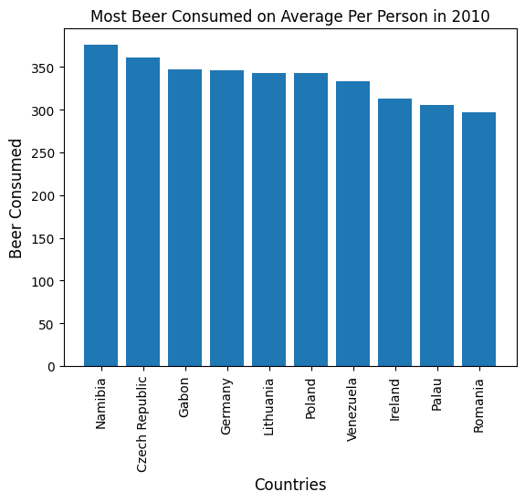

```python
import matplotlib.pyplot as plt
# Create a sub dataset of the top 10 beer drinking countries
highestBeer = drinks.sort_values(by=['beer_servings'], ascending=False)
highestBeer = highestBeer.head(10)[["country", "beer_servings"]]

# Create lists for the x and y axis
countries = highestBeer["country"].values.tolist()
servings = highestBeer["beer_servings"].values.tolist()

# Create bar graph
fig,ax = plt.subplots(nrows=1, ncols=1)
ax.bar(countries, servings)
plt.xlabel('Countries', fontsize = 12)
plt.ylabel('Beer Consumed', fontsize=12)
plt.xticks(rotation='vertical', fontsize=10)
plt.title("Most Beer Consumed on Average Per Person in 2010", fontsize=12)

plt.show()
```

When running this code, we can see that from all the countrys in the dataset, Namibia has the highest beer servings per person at 376 beers. This is surprising considering European countries like Germany are known for their beer. Same with Ireland with their Guinness.

Q2: Which country has the lowest spirit servings?

```python
lowestSpirit = drinks.sort_values(by=['spirit_servings'], ascending=True)
lowestSpirit.head(10)[["country", "spirit_servings"]]
```

|  | country | spirit_servings |
| --- | --- | --- |
| 0 | Afghanistan | 0 |
| 27 | Burundi | 0 |
| 128 | Pakistan | 0 |
| 118 | Nauru | 0 |
| 111 | Monaco | 0 |
| 46 | North Korea | 0 |
| 107 | Mauritania | 0 |
| 106 | Marshall Islands | 0 |
| 103 | Maldives | 0 |
| 55 | Equatorial Guinea | 0 |

When running this code we can see that many countries are tied for having the least amount of spirit at 0 servings per person.

Q3: Which countries have had the most amount of litres of pure alcohol?

```python
mostAlcohol = drinks.sort_values(by=['total_litres_of_pure_alcohol'], ascending=False)
mostAlcohol.head(10)[['country','total_litres_of_pure_alcohol']]
```

|  | country | total_litres_of_pure_alcohol |
| --- | --- | --- |
| 15 | Belarus | 14.4 |
| 98 | Lithuania | 12.9 |
| 3 | Andorra | 12.4 |
| 68 | Grenada | 11.9 |
| 45 | Czech Republic | 11.8 |
| 61 | France | 11.8 |
| 141 | Russian Federation | 11.5 |
| 81 | Ireland | 11.4 |
| 155 | Slovakia | 11.4 |
| 99 | Luxembourg | 11.4 |

When running this code we can see that out of all countries in the database, Belarus has the highest amount of litres of alcohol per person at 14.4 liters.

Q4: Which countries have 0 wine consumption?

```python
noWine = drinks.sort_values(by=['wine_servings'], ascending=True)
noWine.head(15)[['country', 'wine_servings']]
```

|  | country | wine_servings |
| --- | --- | --- |
| 0 | Afghanistan | 0 |
| 27 | Burundi | 0 |
| 116 | Myanmar | 0 |
| 107 | Mauritania | 0 |
| 106 | Marshall Islands | 0 |
| 103 | Maldives | 0 |
| 102 | Malaysia | 0 |
| 97 | Libya | 0 |
| 119 | Nepal | 0 |
| 95 | Lesotho | 0 |
| 46 | North Korea | 0 |
| 80 | Iraq | 0 |
| 79 | Iran | 0 |
| 78 | Indonesia | 0 |
| 77 | India | 0 |

Looking at this list of countries that consume an average of 0 servings of wine in 2010, India is one country that surprised us. Seeing as there are vineyards in India, it's surprising to see a 0 average. My only guess could be that since the population of India is so large that wine is not commonly consumed, so that would bring the average down.

Q5: What is the average amount of beer consumed by all the countries that drink beer?

```python
consumeBeer = drinks[drinks.beer_servings != 0]
avgBeer = drinks.loc[:, 'beer_servings'].mean()
print("Average servings of beer for all beer drinking countries:", round(avgBeer), "beers")
print("Number of beer consuming countries:", len(consumeBeer.index))
```

[output not shown]

Q6: What is the average amount of liters of pure alcohol consumed by alcohol consuming countries?

```python
pureAlcConsumed = drinks[drinks.total_litres_of_pure_alcohol != 0]
avgPureAlc = drinks.loc[:, 'total_litres_of_pure_alcohol'].mean()
print("Average liters of pure alcohol consumed:", round(avgPureAlc, 2))
print("Number of pure alcohol consuming countries:", len(pureAlcConsumed.index))
```

[output not shown]

# Closing Remarks

Overall, throughout our data exploration we can see which countries consumes alcohol a good amount, and others that consume very little or none at all. If you look into the history of the countries that drink a lot of none at all, you can draw conclusions on why this might be the case. In conclusion, it is very interesting to see how different religions, cultures, and climates can affect alcohol consumption.